# Collisions

Eugene

Friday, 19 March, 2021

## Theory

This week we’re going to do a lab based on the **conservation of momentum** and **coefficient of resititution**. We’re going to let objects collide, see how their momenta change, and examine the effects of elastic collisions. There won’t be any graphs this week, but there will be quite a few tables.

## Set-Up and Results

Go to the collisions experiment on the [PHET website](https://phet.colorado.edu/sims/html/collision-lab/latest/collision-lab_en.html). Go to the **Intro** tag here.

1. Check the box **Kinetic Energy** on the right and the box **More Data** on the left. Adjust the **Elasticity** slider to read 0%.  
   Record the *Kinetic Energy* (0.44J here) and all the values in the *More Data* box (the *Mass*, *Position*, *Velocity*, and *Momentum*).  
   Press **Play**.

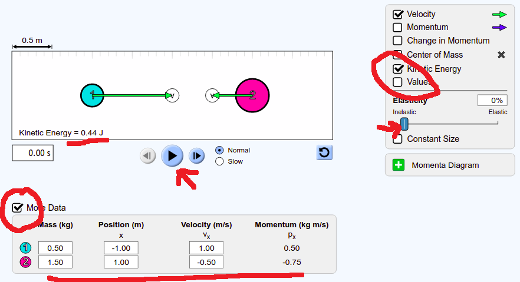

2. Once the collision has ocurred, press the **Pause** button. Record the new values for the *Kinetic Energy* and the values in the *More Data* box. When you have done this, refresh the demo by pressing the blue button to the bottom right of the collision screen.

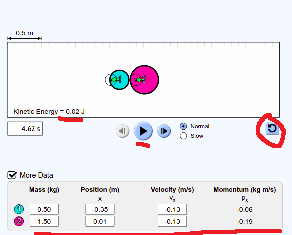

3. Readjust the **Elasticity** slider to 20%. Repeat the measurements from steps 1 and 2 above. Do this again for **Elasticity** set to 40%, 60%, 80%, and 100%.

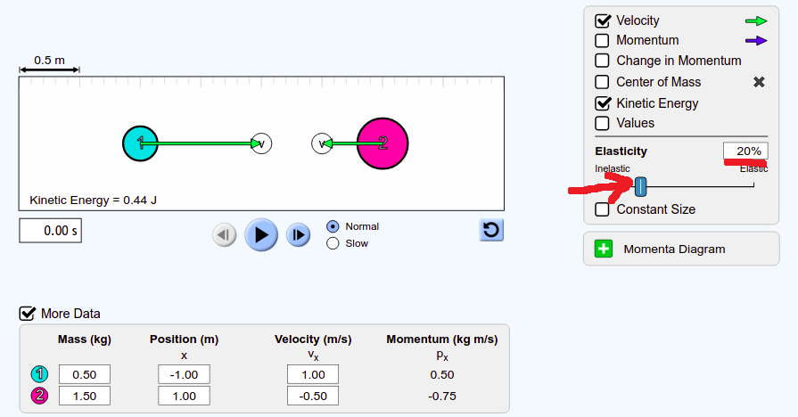

## Data

Fill out a series of tables, one for each setting of **Elasticity**. For the values seen above, this is shown here:

Results for Elasticity = 0%

|  | **Mass (kg)** | **V<sub>0</sub> (m/s)** | **Momentum<sub>0</sub> (kg m/s)** | **KE<sub>0</sub> (J)** | **V<sub>final</sub> (m/s)** | **Momentum<sub>final</sub> (kg m/s)** | **KE<sub>final</sub> (J)** |
| --- | --- | --- | --- | --- | --- | --- | --- |
| mass_1 | 0.5 | 1.0 | 0.50 | 0.25<sup>1</sup> | -0.13 | -0.06 | 0.004<sup>1</sup> |
| mass_2 | 1.5 | -0.5 | -0.75 | 0.19<sup>1</sup> | -0.13 | -0.19 | 0.013<sup>1</sup> |
| Total | NA | 1.5<sup>2</sup> | -0.25 | 0.44 | 0.00<sup>2</sup> | -0.25 | 0.020 |

<sup>*1*</sup> Calculated using ½mv<sup>2</sup> <sup>*2*</sup> Calculated by the difference between the velocity of mass<sub>1</sub> and mass<sub>2</sub>

## Analysis

For each table, calculate the **Coefficient of Restitution** by dividing the velocity of separation after the collision by the velocity of approach before the collision. For the table above, this is done by:

$$COR\:=\: \frac{velocity\;of\;separation}{velocity\;of\;approach}\:=\: \frac{0}{1.5}\:=\: 0.0$$
Calculate the amount of kinetic energy lost in the collision by subtracting the $KE_{final}$ from $KE_0$. For the table above this would be:

$$Kinetic\:Energy\:Lost\:=\:KE_0\:-\:KE_{final}\:=\:0.44\:-\:0.02\:=\:0.42\:J$$

## Discussion

Make a table of your results, filling it out as below:

Overall Results

| **Elasticity (%)** | **Coeff. of Restitution** | **Kinetic Energy Lost (J)** |
| --- | --- | --- |
| 0 | 0 | 0.42 |
| 20 |  |  |
| 40 |  |  |
| 60 |  |  |
| 80 |  |  |
| 100 |  |  |

For this lab, we can’t really discuss inaccuracies, but your discussion section should include a discussion of how our results relate to **momentum conservation** and **energy loss in inelastic collisions**.